# Homework2

Wenyu Zhu

2020/6/5

```r
# Load Packages
library(nlme)
library(lme4)
library(coxme)
library(ggplot2)
library(readr)
library(GGally)
```

# Question 1

## Import data

```r
# Load Data
dat1 <- read_csv("progression.csv")
colnames(dat1) <- c("Subject", "Follow_up_time", "Progression", "Age","Center",
                    "Treament")

# View data
head(dat1)
```

```
## # A tibble: 6 x 6
##   Subject Follow_up_time Progression   Age Center Treament
##     <dbl>          <dbl>       <dbl> <dbl> <chr>  <chr>
## 1       1             34           1    63 MSKCC  Whipple procedure
## 2       2             36           1    68 MSKCC  Distal pancreatectomy
## 3       3              6           1    52 MSKCC  Whipple procedure
## 4       4             42           1    44 MSKCC  Whipple procedure
## 5       5             11           1    64 MSKCC  Distal pancreatectomy
## 6       6             12           1    62 MSKCC  Whipple procedure
```

```r
# Look at structure of the data
str(dat1)
```

```
## Classes 'spec_tbl_df', 'tbl_df', 'tbl' and 'data.frame': 98 obs. of  6 variables:
##  $ Subject       : num  1 2 3 4 5 6 7 8 9 10 ...
##  $ Follow_up_time: num  34 36 6 42 11 12 48 43 23 33 ...
##  $ Progression   : num  1 1 1 1 1 1 0 0 1 1 ...
##  $ Age           : num  63 68 52 44 64 62 52 55 52 51 ...
##  $ Center        : chr  "MSKCC" "MSKCC" "MSKCC" "MSKCC" ...
##  $ Treament      : chr  "Whipple procedure" "Distal pancreatectomy" "Whipple procedure" "Whipple procedure" ...
##  - attr(*, "spec")=
##   .. cols(
##   ..   Subject = col_double(),
##   ..   `Follow Up Time (Months)` = col_double(),
##   ..   Progression = col_double(),
##   ..   Age = col_double(),
##   ..   Center = col_character(),
##   ..   Treatment = col_character()
##   .. )
```

```r
# relevel the treatment
dat1$Treament=relevel(factor(dat1$Treament), ref = "Whipple procedure")

# Check for missing values
sum(is.na(dat1))
```

```
## [1] 0
```

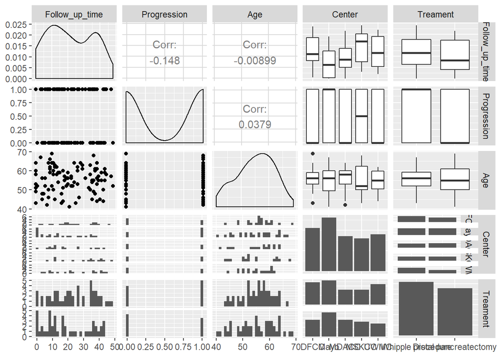

```r
# There is no missing values

# View the data
ggpairs(dat1[,2:6])
```

## Model

```r
#Model Building

a <- coxme(Surv(Follow_up_time, Progression) ~ Age + Treament  + (1|Center),
           data = dat1)
summary(a)
```

```
## Cox mixed-effects model fit by maximum likelihood
##   Data: dat1
##   events, n = 50, 98
##   Iterations= 20 84
##                     NULL Integrated    Fitted
## Log-likelihood -187.1037  -185.1828 -181.7499
##
##                   Chisq   df        p   AIC   BIC
## Integrated loglik  3.84 3.00 0.279050 -2.16 -7.89
##  Penalized loglik 10.71 4.61 0.045471  1.48 -7.34
##
## Model:  Surv(Follow_up_time, Progression) ~ Age + Treament + (1 | Center)
## Fixed coefficients
##                                      coef exp(coef)   se(coef)    z    p
## Age                           0.005940667  1.005958 0.02310353 0.26 0.80
## TreamentDistal pancreatectomy 0.043849863  1.044825 0.29424541 0.15 0.88
##
## Random effects
##  Group  Variable  Std Dev   Variance
##  Center Intercept 0.4505264 0.2029741
```

```r
# Interaction
b <- coxme(Surv(Follow_up_time, Progression) ~ Age*Treament  + (1|Center),
           data = dat1)
summary(b)
```

```
## Cox mixed-effects model fit by maximum likelihood
##   Data: dat1
##   events, n = 50, 98
##   Iterations= 16 68
##                     NULL Integrated    Fitted
## Log-likelihood -187.1037  -185.1325 -181.7865
##
##                   Chisq   df        p   AIC    BIC
## Integrated loglik  3.94 4.00 0.413850 -4.06 -11.71
##  Penalized loglik 10.63 5.56 0.080431 -0.48 -11.11
##
## Model:  Surv(Follow_up_time, Progression) ~ Age * Treament + (1 | Center)
## Fixed coefficients
##                                          coef exp(coef)   se(coef)     z    p
## Age                                0.01407702 1.0141766 0.03435651  0.41 0.68
## TreamentDistal pancreatectomy      0.87689859 2.4034341 2.61793219  0.33 0.74
## Age:TreamentDistal pancreatectomy -0.01503117 0.9850812 0.04693853 -0.32 0.75
##
## Random effects
##  Group  Variable  Std Dev   Variance
##  Center Intercept 0.4391567 0.1928586
```

```r
# Compare the two models
anova(a,b)
```

```
## Analysis of Deviance Table
##  Cox model: response is  Surv(Follow_up_time, Progression)
##  Model 1: ~Age + Treament + (1 | Center)
##  Model 2: ~Age * Treament + (1 | Center)
##    loglik  Chisq Df P(>|Chi|)
## 1 -185.18
## 2 -185.13 0.1005  1    0.7512
```

## Result

**Model Specification**

$h_{ij}(t)$: Hazard at time t for Subject j in Center i.

$h_{0}(t)$: Baseline hazard at time t.

$\beta_1$: Fixed main effect of age.

$\beta_2$: Fixed main effect of treatment.

$\beta_3$: Interaction effect of age and treatment.

$Treatment_{ij}$: Indicator that Subject j with center i, equalling 1, when treatment is Distal pancreatectomy or 0 when treatment is Whipple procedure.

$b_i \sim N(0,\sigma_b^2)$. Random effect of Center i.

Model without interaction: $h_{ij}(t)=h_0(t)exp(\beta_1Age_{ij}+\beta_2Treatment_{ij}+b_i)$

Model with interaction: $h_{ij}(t)=h_0(t)exp(\beta_1Age_{ij}+\beta_2Treatment_{ij}+\beta_3Age_{ij}Treatment_{ij}+b_i)$

From anova test, we can see that the two models are not significant different with p=0.75, so we can use the simpler model. From the summary part, we can see that the coefficient of the interaction of age and treatment is -0.015, which is near 0, so we can use the model without interaction to estimate the relationship between progression and other variables.

Mixed Effect Cox-Regression without interaction:

There is no statistically signifiant associate between progression and other variables.

# Question 2

## Import data

```r
# Load Data
dat2 <- read_csv("sleep24ap.csv")
dat2$AppIn<-factor(dat2$AppIn,levels=c(0,1),labels=c("No","Yes"))

# View data
head(dat2)
```

```
## # A tibble: 6 x 4
##   Subject   BMI SLEEP AppIn
##     <dbl> <dbl> <chr> <fct>
## 1       1  27.1 N     Yes
## 2       1  27.1 L     No
## 3       1  27.1 L     Yes
## 4       1  27.1 N     No
## 5       2  29.1 L     Yes
## 6       2  29.1 N     No
```

```r
# Look at structure of the data
str(dat2)
```

```
## Classes 'spec_tbl_df', 'tbl_df', 'tbl' and 'data.frame': 24 obs. of  4 variables:
##  $ Subject: num  1 1 1 1 2 2 2 2 3 3 ...
##  $ BMI    : num  27.1 27.1 27.1 27.1 29.1 29.1 29.1 29.1 29 29 ...
##  $ SLEEP  : chr  "N" "L" "L" "N" ...
##  $ AppIn  : Factor w/ 2 levels "No","Yes": 2 1 2 1 2 1 1 2 1 1 ...
##  - attr(*, "spec")=
##   .. cols(
##   ..   Subject = col_double(),
##   ..   BMI = col_double(),
##   ..   SLEEP = col_character(),
##   ..   AppIn = col_double()
##   .. )
```

```r
# Check for missing values
sum(is.na(dat2))
```

```
## [1] 0
```

```r
# There is no missing values

# draw the table between sleep and appln
table(dat2$SLEEP,dat2$AppIn)
```

```
##
##     No Yes
##   L  4   8
##   N  7   5
```

## Model

**GLMM Model without interaction**

```r
# transform AppIN
dat2$AppIn<-factor(dat2$AppIn,levels = c("Yes","No"),labels = c(1,0))
dat2$SLEEP<-relevel(factor(dat2$SLEEP),ref = "N")
# Model Building
c <-  glmer(AppIn ~ BMI + SLEEP + (1|Subject),
                  family = binomial(link = "logit"),
            data = dat2)
```

```
## boundary (singular) fit: see ?isSingular
```

```r
summary(c)
```

```
## Generalized linear mixed model fit by maximum likelihood (Laplace
##   Approximation) [glmerMod]
##  Family: binomial  ( logit )
## Formula: AppIn ~ BMI + SLEEP + (1 | Subject)
##    Data: dat2
##
##      AIC      BIC   logLik deviance df.resid
##     39.4     44.1    -15.7     31.4       20
##
## Scaled residuals:
##     Min      1Q  Median      3Q     Max
## -1.1885 -0.8399 -0.6427  0.8646  1.5249
##
## Random effects:
##  Groups  Name        Variance Std.Dev.
##  Subject (Intercept) 0        0
## Number of obs: 24, groups:  Subject, 6
##
## Fixed effects:
##             Estimate Std. Error z value Pr(>|z|)
## (Intercept) -1.68242    5.00754  -0.336    0.737
## BMI          0.06921    0.17075   0.405    0.685
## SLEEPL      -1.03709    0.85100  -1.219    0.223
##
## Correlation of Fixed Effects:
##        (Intr) BMI
## BMI    -0.993
## SLEEPL -0.038 -0.043
## convergence code: 0
## boundary (singular) fit: see ?isSingular
```

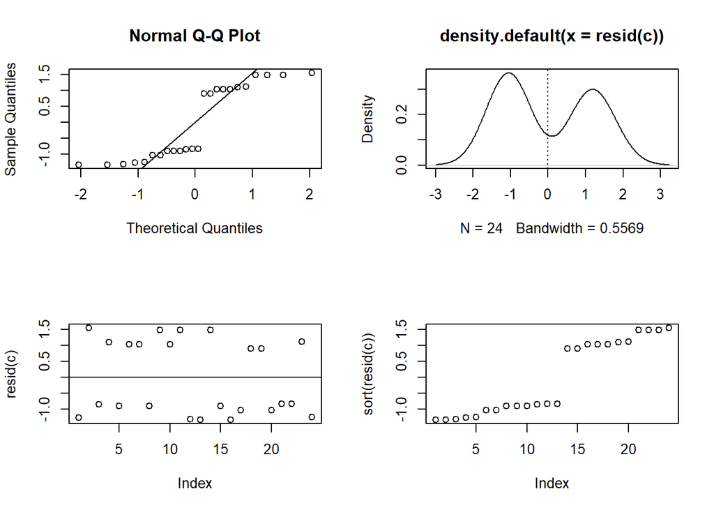

```r
# Check Model Assumptions
par(mfrow = c(2,2))
qqnorm(resid(c))
qqline(resid(c))
plot(density(resid(c)))
abline(v=0,lty=3)

#Homoskedasticity
plot(resid(c))
abline(h=0)

#Outliers
plot(sort(resid(c)))
```

```r
#Normality
shapiro.test(resid(c))
```

```
##
##  Shapiro-Wilk normality test
##
## data:  resid(c)
## W = 0.78808, p-value = 0.0001893
```

**GLMM Model with interaction**

```r
# Interaction
d <-  glmer(AppIn ~ BMI*SLEEP + (1|Subject),
                  family = binomial(link = "logit"),
            data = dat2)
```

```
## boundary (singular) fit: see ?isSingular
```

```r
summary(d)
```

```
## Generalized linear mixed model fit by maximum likelihood (Laplace
##   Approximation) [glmerMod]
##  Family: binomial  ( logit )
## Formula: AppIn ~ BMI * SLEEP + (1 | Subject)
##    Data: dat2
##
##      AIC      BIC   logLik deviance df.resid
##     39.7     45.6    -14.9     29.7       19
##
## Scaled residuals:
##     Min      1Q  Median      3Q     Max
## -1.2551 -0.8390 -0.4587  0.9162  1.4470
##
## Random effects:
##  Groups  Name        Variance Std.Dev.
##  Subject (Intercept) 5.44e-17 7.376e-09
## Number of obs: 24, groups:  Subject, 6
##
## Fixed effects:
##             Estimate Std. Error z value Pr(>|z|)
## (Intercept)  -9.3596     9.2105  -1.016    0.310
## BMI           0.3350     0.3207   1.044    0.296
## SLEEPL       13.4736    12.2848   1.097    0.273
## BMI:SLEEPL   -0.5006     0.4265  -1.174    0.241
##
## Correlation of Fixed Effects:
##            (Intr) BMI    SLEEPL
## BMI        -0.998
## SLEEPL     -0.750  0.748
## BMI:SLEEPL  0.750 -0.752 -0.997
## convergence code: 0
## boundary (singular) fit: see ?isSingular
```

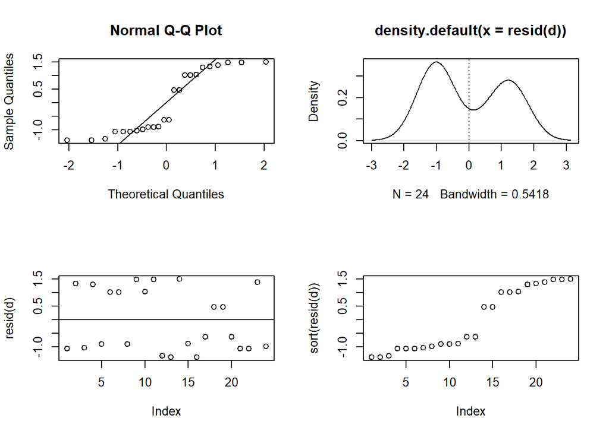

```r
# Check Model Assumptions
par(mfrow = c(2,2))
qqnorm(resid(d))
qqline(resid(d))
plot(density(resid(d)))
abline(v=0,lty=3)

#Homoskedasticity
plot(resid(d))
abline(h=0)

#Outliers
plot(sort(resid(d)))
```

```r
#Normality
shapiro.test(resid(d))
```

```
##
##  Shapiro-Wilk normality test
##
## data:  resid(d)
## W = 0.81895, p-value = 0.0006111
```

For both models:

Residuals look skewed (density/QQ plot). Residuals look randomly distributed, so there is no obvious heteroscedascity. There are some outliers seen in last plot at the tail. Shapiro test shows significance for non-normality (p < 0.001).

**Comparing two models**

```r
# Camparing model with out interaction and model with interaction
anova(c,d)
```

```
## Data: dat2
## Models:
## c: AppIn ~ BMI + SLEEP + (1 | Subject)
## d: AppIn ~ BMI * SLEEP + (1 | Subject)
##   npar    AIC    BIC  logLik deviance  Chisq Df Pr(>Chisq)
## c    4 39.412 44.124 -15.706   31.412
## d    5 39.734 45.625 -14.867   29.734 1.6774  1     0.1953
```

**Check the random effect of the model**

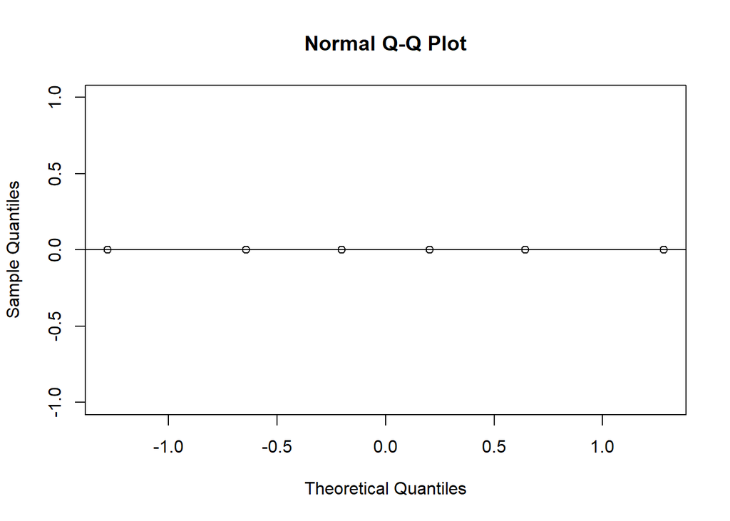

```r
# Check normality and variance of the random effects
reffects <- unlist(ranef(c))
qqnorm(reffects)
qqline(reffects)
```

According to the results, the variance of subject is 0, there is no need to add it as random effects.

**GLM model(without random effect)**

```r
e <-  glm(AppIn ~ BMI + SLEEP,
                  family = binomial(link = "logit"),
            data = dat2)
summary(e)
```

```
##
## Call:
## glm(formula = AppIn ~ BMI + SLEEP, family = binomial(link = "logit"),
##     data = dat2)
##
## Deviance Residuals:
##     Min       1Q   Median       3Q      Max
## -1.3272  -1.0332  -0.8316   1.0564   1.5502
##
## Coefficients:
##             Estimate Std. Error z value Pr(>|z|)
## (Intercept) -1.68242    5.00785  -0.336    0.737
## BMI          0.06921    0.17076   0.405    0.685
## SLEEPL      -1.03709    0.85100  -1.219    0.223
##
## (Dispersion parameter for binomial family taken to be 1)
##
##     Null deviance: 33.104  on 23  degrees of freedom
## Residual deviance: 31.412  on 21  degrees of freedom
## AIC: 37.412
##
## Number of Fisher Scoring iterations: 4
```

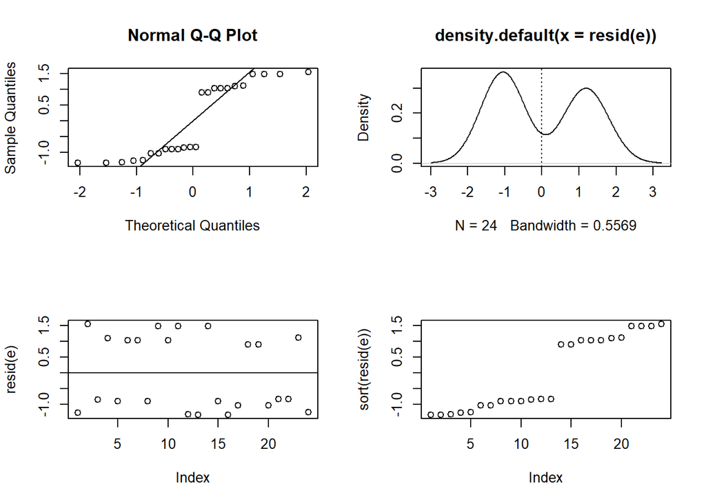

```r
# Check Model Assumptions
par(mfrow = c(2,2))
qqnorm(resid(e))
qqline(resid(e))
plot(density(resid(e)))
abline(v=0,lty=3)

#Homoskedasticity
plot(resid(e))
abline(h=0)

#Outliers
plot(sort(resid(e)))
```

```r
#Normality
shapiro.test(resid(e))
```

```
##
##  Shapiro-Wilk normality test
##
## data:  resid(e)
## W = 0.78808, p-value = 0.0001893
```

```r
# Campaing model withour interaction and model without random effect
anova(c,e)
```

```
## Data: dat2
## Models:
## e: AppIn ~ BMI + SLEEP
## c: AppIn ~ BMI + SLEEP + (1 | Subject)
##   npar    AIC    BIC  logLik deviance Chisq Df Pr(>Chisq)
## e    3 37.412 40.946 -15.706   31.412
## c    4 39.412 44.124 -15.706   31.412     0  1          1
```

Residuals look skewed (density/QQ plot). Residuals look randomly distributed, so there is no obvious heteroscedascity. There are some outliers seen in last plot at the tail. Shapiro test shows significance for non-normality (p < 0.001).

## Result

**Model Specification**

$p_{ij}$: Probability of response for Subject i with appetite increase j.

$b_i \sim N(0,\sigma_b^2)$. Random effect of subject i.

$\beta_1$: Fixed main effect of sleep.

$\beta_2$: Fixed main effect of BMI.

$\beta_3$: Interaction effect of sleep status and BMI.

$1_{ij}$: Indicator that Subject i with appetite increase j had late sleep.

Model without interaction(GLMM): $logit(p_{ij})=\alpha+b_i+\beta_11_{ij}+\beta_2BMI_{ij}$

Model with interaction(GLMM): $logit(p_{ij})=\alpha+b_i+\beta_11_{ij}+\beta_2BMI_{ij}+\beta_31_{ij}BMI_{ij}$

Model without random effect(GLM): $logit(p_{ij})=\alpha+\beta_11_{ij}+\beta_2BMI_{ij}$

Using ANOVA to compare model without interaction and model without random effect. From the result, with p = 1, we can conclude that there is no significant difference between these models, so I choose the model without random effect due to smaller AIC and BIC.

There is no statistically significant sleep effect on appetite increase as noted by the estimate and p value (est=-1.03709; p=0.223) and there is no statistically significant BMI effect on appetite increase as noted by the estimate and p value (est=0.06921; p=0.685)